# 5. Divide and Conquer II

Algorithm II

5. Divide and Conquer II

WU Xiaokun 吴晓堃

xkun.wu [at] gmail

2021/10/29

# Master theorem

## DnC recurrences

**Goal**. Recipe for solving general divide-and-conquer recurrences:

$$T(n) = a T(\frac{n}{b}) + f(n)$$

with $T(0) = 0$ and $T(1) = \Theta(1)$.

**Terms**.

- $a \ge 1$: number of sub-problems.
- $b \ge 2$: factor by which the subproblem size decreases.
- $f(n) \ge 0$: work to divide and combine sub-problems.

## Recursion tree

Suppose $T(n) = a T (n / b) + n^c$, with $T(1) = 1$ and $n$ a power of $b$.

- $a$: branching factor.
- $a^i$: number of sub-problems at level $i$.
- $1 + \log_b n$ levels.
- $n / b^i$: size of subproblem at level $i$.

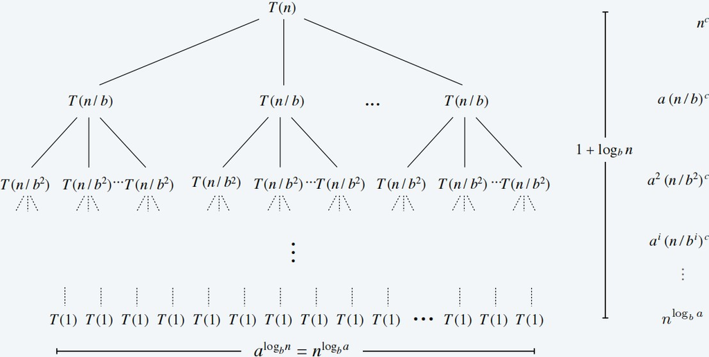

## Recursion tree (cont.)

Suppose $T(n) = a T (n / b) + n^c$, with $T(1) = 1$ and $n$ a power of $b$.

- Let $r = a / b^c$, then $T(n) = n^c \sum_{i=0}^{\log_b n} r^i$.

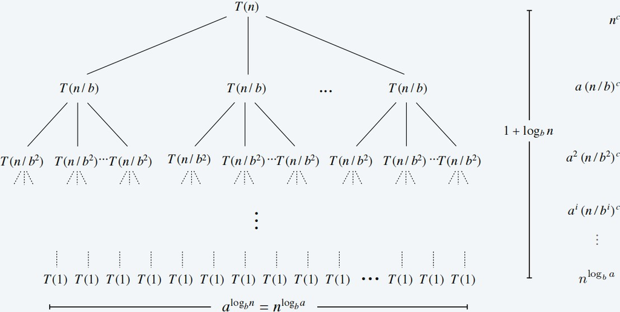

Note the last one on the right: $a^{\log_b n} (\frac{n}{b^{\log_b n}})^c = n^{\log_b a} (\frac{n}{n})^c = n^{\log_b a}$.

## Recursion tree: analysis

Suppose $T(n) = a T (n / b) + n^c$, with $T(1) = 1$ and $n$ a power of $b$.

- Let $r = a / b^c$. Note that $r < 1$ iff $c > log_b a$.

$$T(n) = n^c \sum_{i=0}^{\log_b n} r^i = \left\{ \begin{array}{lcl}
\Theta(n^c) & \text{if} & r < 1, \text{ie. cost dominated by root}\\
\Theta(n^c \log n) & \text{if} & r = 1, \text{ie. cost evenly distributed}\\
\Theta(n^{\log_b a}) & \text{if} & r > 1, \text{ie. cost dominated by leaves}\\
\end{array}\right.$$

**Geometric series**.

- If $0 < r < 1$, then $1 + r + r^2 + r^3 + \ldots + r^k \le 1 / (1 − r)$.
- If $r = 1$, then $1 + r + r^2 + r^3 + \ldots + r^k = k + 1$.
- If $r > 1$, then $1 + r + r^2 + r^3 + \ldots + r^k = (r^{k+1} − 1) / (r − 1)$.

## DnC: Master theorem

### Master theorem

Let $a \ge 1, b \ge 2, c \ge 0$ and suppose $T(n)$ is a function on non-negative integers that satisfies the recurrence $T(n) = a T (n / b) + \Theta(n^c)$ with $T(0) = 0, T(1) = \Theta(1)$, where $n / b$ means either $\lfloor n / b \rfloor$ or $\lceil n / b \rceil$. Then,

**Case 1**. If $c > \log_b a$, then $T(n) = \Theta(n^c)$.  
**Case 2**. If $c = \log_b a$, then $T(n) = \Theta(n^c \log n)$.  
**Case 3**. If $c < \log_b a$, then $T(n) = \Theta(n^{\log_b a})$.

**Pf sketch**.

- Prove when $b$ is an integer and $n$ is an exact power of $b$.
- Extend domain of recurrences to reals (or rationals).
- Deal with floors and ceilings.

## DnC: Master theorem extensions

### Master theorem

Let $a \ge 1, b \ge 2, c \ge 0$ and suppose $T(n)$ is a function on non-negative integers that satisfies the recurrence $T(n) = a T (n / b) + \Theta(n^c)$ with $T(0) = 0, T(1) = \Theta(1)$, where $n / b$ means either $\lfloor n / b \rfloor$ or $\lceil n / b \rceil$. Then,

**Case 1**. If $c > \log_b a$, then $T(n) = \Theta(n^c)$.  
**Case 2**. If $c = \log_b a$, then $T(n) = \Theta(n^c \log n)$.  
**Case 3**. If $c < \log_b a$, then $T(n) = \Theta(n^{\log_b a})$.

**Extensions**.

- Can replace $\Theta$ with $O$ everywhere.
- Can replace $\Theta$ with $\Omega$ everywhere.
- Can replace initial conditions with $T(n) = \Theta(1)$ for all $n \le n_0$ and require recurrence to hold only for all $n > n_0$.

### Master theorem

Let $a \ge 1, b \ge 2, c \ge 0$ and suppose $T(n)$ is a function on non-negative integers that satisfies the recurrence $T(n) = a T (n / b) + \Theta(n^c)$ with $T(0) = 0, T(1) = \Theta(1)$, where $n / b$ means either $\lfloor n / b \rfloor$ or $\lceil n / b \rceil$. Then,

**Case 1**. If $c > \log_b a$, then $T(n) = \Theta(n^c)$.  
**Case 2**. If $c = \log_b a$, then $T(n) = \Theta(n^c \log n)$.  
**Case 3**. If $c < \log_b a$, then $T(n) = \Theta(n^{\log_b a})$.

- $a = 3, b = 2, c = 1 < \log_b a = 1.5849...$.
- $T(n) = \Theta(n^{log_2 3}) = O(n^{1.58})$.

## DnC: Master theorem - case 2

### Master theorem

Let $a \ge 1, b \ge 2, c \ge 0$ and suppose $T(n)$ is a function on non-negative integers that satisfies the recurrence $T(n) = a T (n / b) + \Theta(n^c)$ with $T(0) = 0, T(1) = \Theta(1)$, where $n / b$ means either $\lfloor n / b \rfloor$ or $\lceil n / b \rceil$. Then,

**Case 1**. If $c > \log_b a$, then $T(n) = \Theta(n^c)$.  
**Case 2**. If $c = \log_b a$, then $T(n) = \Theta(n^c \log n)$.  
**Case 3**. If $c < \log_b a$, then $T(n) = \Theta(n^{\log_b a})$.

**Ex**. [Case 2] $T(n) = T(\lfloor n / 2 \rfloor) + T(\lceil n / 2 \rceil) + 17 n$.

- $a = 2, b = 2, c = 1 = \log_b a$.
- $T(n) = \Theta(n \log n)$.

### Master theorem

Let $a \ge 1, b \ge 2, c \ge 0$ and suppose $T(n)$ is a function on non-negative integers that satisfies the recurrence $T(n) = a T (n / b) + \Theta(n^c)$ with $T(0) = 0, T(1) = \Theta(1)$, where $n / b$ means either $\lfloor n / b \rfloor$ or $\lceil n / b \rceil$. Then,

**Case 1**. If $c > \log_b a$, then $T(n) = \Theta(n^c)$.  
**Case 2**. If $c = \log_b a$, then $T(n) = \Theta(n^c \log n)$.  
**Case 3**. If $c < \log_b a$, then $T(n) = \Theta(n^{\log_b a})$.

- $a = 48, b = 4, c = 3 > \log_b a = 2.7924...$.
- $T(n) = \Theta(n^3)$.

## DnC: Master theorem - exceptions

**Gaps in master theorem**.

- Number of sub-problems is not a constant.
  - $T(n) = n T(n/2) + n^2$
- Number of sub-problems is less than 1.
  - $T(n) = \frac{1}{2} T(n/2) + n^2$
- Work to divide and combine sub-problems is not $\Theta(n^c)$.
  - $T(n) = 2 T(n/2) + n \log n$

## Akra–Bazzi theorem

### Theorem. [Akra–Bazzi 1998]

Let $a_1 > 0, 0 < b_i < 1$, functions $|h_i(n)| = O(n / \log^2 n)$ and $g(n) = O(n^c)$. If $T(n)$ satisfies the recurrence:

$$T(n) = \sum_{i=1}^k a_i T(b_i n + h_i(n)) + g(n)$$

then, $T(n) = (n^p (1 + \int_1^n \frac{g(u)}{u^{p+1}}\,du))$, where $p$ satisfies $\sum_{i=1}^k a_i b_i^p = 1$.

**Ex**. $T(n) = T(\lfloor n / 5 \rfloor) + T(n – 3\lfloor n / 10 \rfloor) + 11/5 n$, with $T(0) = 0, T(1) = 0$.

- $a_1 = 1, b_1 = 1/5, a_2 = 1, b2 = 7/10 \Rightarrow p = 0.83978... < 1$.
- $h_1(n) = \lfloor n / 5 \rfloor – n / 5, h_2(n) = 3/10 n – 3\lfloor n / 10 \rfloor$.
- $g(n) = 11/5 n \Rightarrow T(n) = \Theta(n)$.

# Integer multiplication

## Integer addition and subtraction

**Addition**. Given two $n$-bit integers $a$ and $b$, compute $a + b$.

**Subtraction**. Given two $n$-bit integers $a$ and $b$, compute $a – b$.

**Grade-school algorithm**. $\Theta(n)$ bit operations.

| = | 1 | 0 | 1 | 0 | 1 | 0 | 0 | 1 | 0 |
| --- | --- | --- | --- | --- | --- | --- | --- | --- | --- |
|  |  | 1 | 1 | 0 | 1 | 0 | 1 | 0 | 1 |
| + |  | 0 | 1 | 1 | 1 | 1 | 1 | 0 | 1 |
|  | 1 | 1 | 1 | 1 | 1 | 1 | 0 | 1 |  |

**Remark**. Grade-school addition and subtraction algorithms are optimal.

## Integer Multiplication Problem

**Multiplication**. Given two $n$-bit integers $a$ and $b$, compute $a \times b$.  
**Grade-school algorithm (long multiplication)**. $\Theta(n^2)$ bit operations.

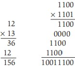

**Conjecture**. [Kolmogorov 1956] Grade-school algorithm is optimal.  
**Theorem**. [Karatsuba 1960] Conjecture is false.

## DnC multiplication

To multiply two $n$-bit integers $x$ and $y$:

- Divide $x$ and $y$ into low- and high-order bits.
  - $m = \lceil n/2 \rceil$
  - $a = \lfloor x / 2^m \rfloor, b = x \mod 2^m$
  - $c = \lfloor y / 2^m \rfloor, d = y \mod 2^m$
- Multiply four $(n/2)$-bit integers, recursively.
- Add and shift to obtain result.

$x y = (2^m a + b) (2^m c + d) = 2^{2m} ac + 2^m (bc + ad) + bd$

**Ex**.

|  | a |  |  |  | b |  |  |  |
| --- | --- | --- | --- | --- | --- | --- | --- | --- |
| x = | 1 | 0 | 0 | 0 | 1 | 1 | 0 | 1 |
| y = | 1 | 1 | 1 | 0 | 0 | 0 | 0 | 1 |

## DnC multiplication: algorithm

1. IF ($n = 1$): RETURN $x \times y$;
2. ELSE:
   1. $m = \lceil n/2 \rceil$;
   2. $a = \lfloor x / 2^m \rfloor, b = x \mod 2^m$;
   3. $c = \lfloor y / 2^m \rfloor, d = y \mod 2^m$;
   4. $e$ = `MULTIPLY`($a, c, m$);
   5. $f$ = `MULTIPLY`($b, d, m$);
   6. $g$ = `MULTIPLY`($b, c, m$);
   7. $h$ = `MULTIPLY`($a, d, m$);
3. RETURN $2^{2m} e + 2^m (g + h) + f$;

**Time**.

- `2.1-2.3`: $\Theta(n)$
- `2.4-2.7`: $4 T(\lceil n/2 \rceil)$
- `3`: $\Theta(n)$

## Quiz: DnC multiplication

How many bit operations to multiply two n-bit integers using the divide-and-conquer multiplication algorithm?

$$T(n) = \left\{ \begin{array}{lcl}
\Theta(1) & \text{if} & n = 1 \\
4 T(\lceil n/2 \rceil) + \Theta(n) & \text{if} & n > 1 \\
\end{array}\right.$$

**A**. $T(n) = \Theta(n^{1/2})$.  
**B**. $T(n) = \Theta(n \log n)$.  
**C**. $T(n) = \Theta(n^{\log_2 3}) = O(n^{1.585})$.  
**D**. $T(n) = \Theta(n^2)$.

D: $T(n) = \Theta(n^{\log_2 4}) = \Theta(n^2)$

## Karatsuba trick

To multiply two $n$-bit integers $x$ and $y$:

- Divide $x$ and $y$ into low- and high-order bits.
  - $m = \lceil n/2 \rceil$
  - $a = \lfloor x / 2^m \rfloor, b = x \mod 2^m$
  - $c = \lfloor y / 2^m \rfloor, d = y \mod 2^m$
- To compute middle term $bc + ad$, use identity:
  - $bc + ad = ac + bd – (a – b) (c – d)$
- Multiply only *three* $(n/2)$-bit integers, recursively.
  - reuse: $ac$ and $bd$.

$$\begin{aligned}
x y = (2^m a + b) (2^m c + d) & = 2^{2m} ac + 2^m (bc + ad) + bd \\
& = 2^{2m} ac + 2^m (ac + bd – (a – b) (c – d)) + bd \\
\end{aligned}$$

## Karatsuba multiplication

1. IF ($n = 1$): RETURN $x \times y$;
2. ELSE:
   1. $m = \lceil n/2 \rceil$;
   2. $a = \lfloor x / 2^m \rfloor, b = x \mod 2^m$;
   3. $c = \lfloor y / 2^m \rfloor, d = y \mod 2^m$;
   4. $e$ = `KARATSUBA-MULTIPLY`($a, c, m$);
   5. $f$ = `KARATSUBA-MULTIPLY`($b, d, m$);
   6. $g$ = `KARATSUBA-MULTIPLY`($|a – b|, |c – d|, m$);
   7. Flip sign of $g$ if needed.
3. RETURN $2^{2m} e + 2^m (e + f - g) + f$;

**Time**.

- `2.1-2.3`: $\Theta(n)$
- `2.4-2.6`: $3 T(\lceil n/2 \rceil)$
- `3`: $\Theta(n)$

## Karatsuba analysis

**Proposition**. Karatsuba’s algorithm requires $O(n^{1.585})$ bit operations to multiply two $n$-bit integers.  
**Pf**. Apply Case 3 of the master theorem to the recurrence:

$$T(n) = \left\{ \begin{array}{lcl}
\Theta(1) & \text{if} & n = 1 \\
3 T(\lceil n/2 \rceil) + \Theta(n) & \text{if} & n > 1 \\
\end{array}\right.$$

$\Rightarrow T(n) = \Theta(n^{\log_2 3}) = O(n^{1.585})$

**Practice**.

- Use base-32 or -64 (instead of base-2).
- Faster than grade-school algorithm for about 320–640 bits.

## Integer arithmetic reductions

| arithmetic problem | formula | bit complexity |
| --- | --- | --- |
| integer multiplication | $a \times b$ | $M(n)$ |
| integer square | $a^2$ | $\Theta(M(n))$ |
| integer division | $\lfloor a / b \rfloor, a \mod b$ | $\Theta(M(n))$ |
| integer square root | $\lfloor \sqrt{a} \rfloor$ | $\Theta(M(n))$ |

Integer arithmetic problems have the same bit complexity $M(n)$ as integer multiplication.

# Matrix multiplication

## Dot product

**Dot product**. Given two length-$n$ vectors $a$ and $b$, compute $c = a \cdot b = \sum_{i=1}^n a_i b_i$.  
**Grade-school**. $\Theta(n)$ arithmetic operations.

**Ex**. $a = [.70 .20 .10 ], b = [.30 .40 .30 ]$:

$a \cdot b = (.70 \times .30) + (.20 \times .40) + (.10 \times .30) = .32$

**Remark**. “Grade-school” dot product algorithm is asymptotically optimal.

## Matrix Multiplication Problem

**Matrix multiplication**. Given two $n$-by-$n$ matrices $A$ and $B$, compute $C = AB$.  
**Grade-school**. $\Theta(n^3)$ arithmetic operations.

$$\left[ \begin{array}{c}
c_{11} & c_{12} & \cdots & c_{1n} \\
c_{21} & c_{22} & \cdots & c_{2n} \\
\vdots & \vdots & \ddots & \vdots \\
c_{n1} & c_{n2} & \cdots & c_{nn} \\
\end{array} \right]
=
\left[ \begin{array}{c}
a_{11} & a_{12} & \cdots & a_{1n} \\
a_{21} & a_{22} & \cdots & a_{2n} \\
\vdots & \vdots & \ddots & \vdots \\
a_{n1} & a_{n2} & \cdots & a_{nn} \\
\end{array} \right]
\times
\left[ \begin{array}{c}
b_{11} & b_{12} & \cdots & b_{1n} \\
b_{21} & b_{22} & \cdots & b_{2n} \\
\vdots & \vdots & \ddots & \vdots \\
b_{n1} & b_{n2} & \cdots & b_{nn} \\
\end{array} \right]$$

**Q**. Is “grade-school” matrix multiplication algorithm asymptotically optimal?

## Block matrix multiplication

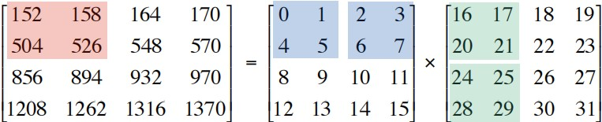

$$\begin{aligned}
C_{11} & = A_{11} \times B_{11} + A_{12} \times B_{21} \\
& = \left[ \begin{array}{c}
0 & 1 \\
4 & 5 \\
\end{array} \right]
\times
\left[ \begin{array}{c}
16 & 17 \\
20 & 21 \\
\end{array} \right]
+
\left[ \begin{array}{c}
2 & 3 \\
6 & 7 \\
\end{array} \right]
\times
\left[ \begin{array}{c}
24 & 25 \\
28 & 29 \\
\end{array} \right] \\
& = \left[ \begin{array}{c}
152 & 158 \\
504 & 526 \\
\end{array} \right] \\
\end{aligned}$$

## Block matrix multiplication: warmup

To multiply two $n$-by-$n$ matrices $A$ and $B$:

- Divide: partition $A$ and $B$ into $n/2$-by-$n/2$ blocks.
- Conquer: multiply 8 pairs of $n/2$-by-$n/2$ matrices, recursively.
- Combine: add appropriate products using 4 matrix additions.

$$\begin{aligned}
C & = A \times B \\
\left[ \begin{array}{c}
C_{11} & C_{12} \\
C_{21} & C_{22} \\
\end{array} \right]
& =
\left[ \begin{array}{c}
A_{11} & A_{12} \\
A_{21} & A_{22} \\
\end{array} \right]
\times
\left[ \begin{array}{c}
B_{11} & B_{12} \\
B_{21} & B_{22} \\
\end{array} \right]
\\
\end{aligned}$$

$$\begin{aligned}
C_{11} & = A_{11} \times B_{11} + A_{12} \times B_{21} \\
C_{12} & = A_{11} \times B_{12} + A_{12} \times B_{22} \\
C_{21} & = A_{21} \times B_{11} + A_{22} \times B_{21} \\
C_{22} & = A_{21} \times B_{12} + A_{22} \times B_{22} \\
\end{aligned}$$

**Running time**. Apply Case 3 of the master theorem.

$T(n) = 8 T(n/2) + \Theta(n^2) \Rightarrow T(n) = \Theta(n^3)$

## Strassen’s trick

**Key idea**. Can multiply two 2-by-2 matrices via 7 scalar multiplications (plus 11 additions and 7 subtractions).

$$\begin{aligned}
\left[ \begin{array}{c}
C_{11} & C_{12} \\
C_{21} & C_{22} \\
\end{array} \right]
& =
\left[ \begin{array}{c}
A_{11} & A_{12} \\
A_{21} & A_{22} \\
\end{array} \right]
\times
\left[ \begin{array}{c}
B_{11} & B_{12} \\
B_{21} & B_{22} \\
\end{array} \right]
\\
\end{aligned}$$
$$\begin{aligned}
C_{11} & = P_5 + P_4 – P_2 + P_6 \\
C_{12} & = P_1 + P_2 \\
C_{21} & = P_3 + P_4 \\
C_{22} & = P_1 + P_5 – P_3 – P_7 \\
\end{aligned}$$

$$\begin{aligned}
P_1 & = A_{11} \times (B_{12} – B_{22}) \\
P_2 & = (A_{11} + A_{12}) \times B_{22} \\
P_3 & = (A_{21} + A_{22}) \times B_{11} \\
P_4 & = A_{22} \times (B_{21} – B_{11}) \\
P_5 & = (A_{11} + A_{22}) \times (B_{11} + B_{22}) \\
P_6 & = (A_{12} – A_{22}) \times (B_{21} + B_{22}) \\
P_7 & = (A_{11} – A_{21}) \times (B_{11} + B_{12}) \\
\end{aligned}$$

**Pf**. $C_{12} = P_1 + P_2 = A_{11} \times (B_{12} – B_{22}) + (A_{11} + A_{12}) \times B_{22} = A_{11} \times B_{12} + A_{12} \times B_{22}$

## Strassen’s algorithm

1. IF ($n = 1$): RETURN $A \times B$;
2. Partition $A$ and $B$ into $n/2$-by-$n/2$ blocks;
3. $P_{1}$ = `STRASSEN`($n / 2, A_{11}, (B_{12} – B_{22})$);
4. $P_{2}$ = `STRASSEN`($n / 2, (A_{11} + A_{12}), B_{22}$);
5. $P_{3}$ = `STRASSEN`($n / 2, (A_{21} + A_{22}), B_{11}$);
6. $P_{4}$ = `STRASSEN`($n / 2, A_{22}, (B_{21} – B_{11})$);
7. $P_{5}$ = `STRASSEN`($n / 2, (A_{11} + A_{22}), (B_{11} + B_{22})$);
8. $P_{6}$ = `STRASSEN`($n / 2, (A_{12} – A_{22}), (B_{21} + B_{22})$);
9. $P_{7}$ = `STRASSEN`($n / 2, (A_{11} – A_{21}), (B_{11} + B_{12})$);
10. $C_{11} = P_{5} + P_{4} – P_{2} + P_{6}$;
11. $C_{12} = P_{1} + P_{2}$;
12. $C_{21} = P_{3} + P_{4}$;
13. $C_{22} = P_{1} + P_{5} – P_{3} – P_{7}$;
14. RETURN C;

**Time**.

- `3-9`: $7 T(n/2) + \Theta(n^2)$
- `10-13`: $\Theta(n^2)$

## Strassen’s algorithm: practice

**Implementation issues**.

- Sparsity.
- Caching.
- n not a power of 2.
- Numerical stability.
- Non-square matrices.
- Storage for intermediate sub-matrices.
- Crossover to classical algorithm when n is “small.”
- Parallelism for multi-core and many-core architectures.

**Common misperception**. “Strassen’s algorithm is only a theoretical curiosity.”

- Apple reports 8x speedup when $n \approx 2,048$.
- Range of instances where it’s useful is a subject of controversy.

## Quiz: matrix multiplication

Suppose that you could multiply two 3-by-3 matrices with 21 scalar multiplications. How fast could you multiply two n-by-n matrices?

**A**. $\Theta(n^{\log_3 21})$  
**B**. $\Theta(n^{\log_2 21})$  
**C**. $\Theta(n^{\log_9 21})$  
**D**. $\Theta(n^2)$

A

## Fast matrix multiplication: theory

**Q**. Multiply two 2-by-2 matrices with 7 scalar multiplications?  
**A**. Yes! [Strassen 1969] $\Theta(n^{\log_2 7}) = O(n^{2.81})$

**Q**. Multiply two 2-by-2 matrices with 6 scalar multiplications?  
**A**. Impossible. [Hopcroft–Kerr, Winograd 1971] $\Theta(n^{\log_2 6}) = O(n^{2.59})$

## Numeric linear algebra reductions

| linear algebra problem | expression | arithmetic complexity |
| --- | --- | --- |
| matrix multiplication | A × B | $MM(n)$ |
| matrix squaring | $A^2$ | $\Theta(MM(n))$ |
| matrix inversion | $A^{–1}$ | $\Theta(MM(n))$ |
| determinant | $\\|A\\|$ | $\Theta(MM(n))$ |
| rank | $rank(A)$ | $\Theta(MM(n))$ |
| system of linear equations | $Ax = b$ | $\Theta(MM(n))$ |
| LU decomposition | $A = L U$ | $\Theta(MM(n))$ |
| least squares | $\min \Vert Ax – b\Vert_2$ | $\Theta(MM(n))$ |

Numerical linear algebra problems have the same arithmetic complexity $MM(n)$ as matrix multiplication

# Convolution and FFT

## Fourier analysis

**Fourier theorem**. [Fourier, Dirichlet, Riemann] Any (sufficiently smooth) *periodic* function can be expressed as the sum of a series of sinusoids.

- transform: *time* domain –> *frequency* domain.

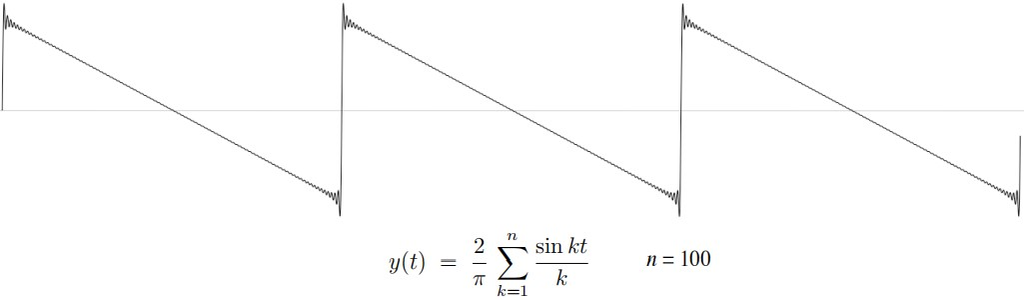

## Euler’s identity

**Euler’s identity**. $e^{ix} = \cos x + i \sin x$.

**Sinusoids**. Sum of sine and cosines = sum of complex exponentials.

- $s_N(x) = \frac{a_0}{2} + \sum_{n=1}^N (a_n \cos(2\pi nx) + b_n \sin(2\pi nx))$
- $s_N(x) = \sum_{n=-N}^N c_n \cdot e^{i 2\pi nx}$

## Fast Fourier transform

**FFT**. Fast way to convert between *time* domain and *frequency* domain.

**Alternate viewpoint**. Fast way to multiply and evaluate *polynomials*.

> “ If you speed up any nontrivial algorithm by a factor of a million or so the world will beat a path towards finding useful applications for it. ” — Numerical Recipes

## Polynomials: coefficient representation

**Univariate polynomial**. [ coefficient representation ]

- $A(x) = a_0 + a_1 x + a_2 x^2 + \ldots + a_{n−1} x^{n−1}$: $a_0, a_1, \ldots + a_{n−1}$
- $B(x) = b_0 + b_1 x + b_2 x^2 + \ldots + b_{n−1} x^{n−1}$: $b_0, b_1, \ldots + b_{n−1}$

**Addition**. $O(n)$ arithmetic operations.

- $A(x) + B(x) = (a_0 + b_0) + (a_1 + b_1) x + \ldots + (a_{n−1} + b_{n−1}) x^{n−1}$

**Evaluation**. $O(n)$ using Horner’s method.

- $A(x) = a_0 + (x(a_1 + x(a_2 + \ldots + x(a_{n−2} + x(a_{n−1})) \ldots))$
  - `for` $j = n-1 .. 0$: $v = a[j] + (x * v)$;

**Multiplication (linear convolution)**. $O(n^2)$ using brute-force.

- $A(x) \times B(x) = \sum_{i=0}^{2n-2} c_i x^i$, where $c_i = \sum_{j=0}^i a_j b_{i-j}$.

## Polynomials: point-value representation

**Fundamental theorem of algebra**. A degree $n$ univariate polynomial with complex coefficients has exactly $n$ complex roots.

**Corollary**. A degree $n – 1$ univariate polynomial $A(x)$ is uniquely specified by its evaluation at $n$ distinct values of $x$.

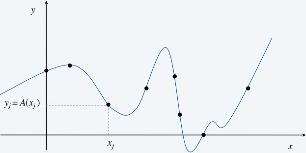

## Polynomials: point-value (cont.)

**Univariate polynomial**. [ point-value representation ]

- $A(x): (x_0, y_0), \ldots, (x_{n-1}, y_{n-1})$
- $B(x): (x_0, z_0), \ldots, (x_{n-1}, z_{n-1})$

**Addition**. $O(n)$ arithmetic operations.

- $A(x) + B(x): (x_0, y_0 + z_0), \ldots, (x_{n-1}, y_{n-1} + z_{n-1})$

**Multiplication**. $O(n)$, but represent $A(x)$ and $B(x)$ using $2n$ points.

- $A(x) \times B(x): (x_0, y_0 \times z_0), \ldots, (x_{2n−1}, y_{2n−1} \times z_{2n−1})$

**Evaluation**. $O(n^2)$ using Lagrange’s formula.

- $A(x) = \sum_{k=0}^{n-1} y_k \frac{\prod_{j \ne k} (x - x_j)}{\prod_{j \ne k} (x_k - x_j)}$

## Representations: tradeoff

**Tradeoff**. Either fast evaluation or fast multiplication. We want both!

| representation | multiply | evaluate |
| --- | --- | --- |
| coefficient | $O(n^2)$ | $O(n)$ |
| point-value | $O(n)$ | $O(n^2)$ |

**Goal**. Efficient conversion between two representations $\Rightarrow$ all ops fast.

## Converting between two representations

**Application**. Polynomial multiplication (coefficient representation).

- exactly the reason to do Fourier transform

| coefficient | transform | point-value |
| --- | --- | --- |
| coefficient | FFT: $O(n \log n)$ | point-value |
|  |  | multiplication: $O(n)$ |
| coefficient | inv. FFT: $O(n \log n)$ | point-value |

## Converting representation: brute-force

**Coefficient $\Rightarrow$ Point-value**. Given a polynomial $A(x) = a_0 + a_1 x + ... + a_{n–1} x^{n–1}$, evaluate it at $n$ distinct points $x_0, ..., x_{n–1}$.

$$\left[ \begin{array}{c}
y_{0} \\
y_{1} \\
y_{2} \\
\vdots \\
y_{n-1} \\
\end{array} \right]
=
\left[ \begin{array}{c}
1 & x_{0} & x_{0}^2 & \cdots & x_{0}^{n-1} \\
1 & x_{1} & x_{1}^2 & \cdots & x_{1}^{n-1} \\
1 & x_{2} & x_{2}^2 & \cdots & x_{2}^{n-1} \\
\vdots & \vdots & \vdots & \ddots & \vdots \\
1 & x_{n-1} & x_{n-1}^2 & \cdots & x_{n-1}^{n-1} \\
\end{array} \right]
\times
\left[ \begin{array}{c}
a_{0} \\
a_{1} \\
a_{2} \\
\vdots \\
a_{n-1} \\
\end{array} \right]$$

## Converting: brute-force (cont.)

**Point-value $\Rightarrow$ Coefficient**. Given $n$ distinct points $x_0, ..., x_{n–1}$ and values $y_0, ..., y_{n–1}$, find unique polynomial $A(x) = a_0 + a_1 x + ... + a_{n–1} x^{n–1}$, that has given values at given points.

$$\left[ \begin{array}{c}
y_{0} \\
y_{1} \\
y_{2} \\
\vdots \\
y_{n-1} \\
\end{array} \right]
=
\left[ \begin{array}{c}
1 & x_{0} & x_{0}^2 & \cdots & x_{0}^{n-1} \\
1 & x_{1} & x_{1}^2 & \cdots & x_{1}^{n-1} \\
1 & x_{2} & x_{2}^2 & \cdots & x_{2}^{n-1} \\
\vdots & \vdots & \vdots & \ddots & \vdots \\
1 & x_{n-1} & x_{n-1}^2 & \cdots & x_{n-1}^{n-1} \\
\end{array} \right]
\times
\left[ \begin{array}{c}
a_{0} \\
a_{1} \\
a_{2} \\
\vdots \\
a_{n-1} \\
\end{array} \right]$$

- Vandermonde matrix is invertible iff $x_i$ distinct.

**Running time**. $O(n^3)$ via Gaussian elimination.

- or $O(n^{2.38})$ via fast matrix multiplication

## Divide-and-conquer

**Decimation in time**. Divide into even- and odd- degree terms.

- $A(x) = a_0+ a_1 x + a_2 x^2 + a_3 x^3+ a_4 x^4 + a_5 x^5 + a_6 x^6 + a_7 x^7$.
- $A_{even}(x) = a_0+ a_2 x + a_4 x^2 + a_6 x^3$.
- $A_{odd}(x) = a_1 + a_3 x + a_5 x^2 + a_7 x^3$.
- $A(x) = A_{even}(x^2) + x A_{odd}(x^2)$.

**Decimation in frequency**. Divide into low- and high-degree terms.

- $A(x) = a_0+ a_1 x + a_2 x^2 + a_3 x^3+ a_4 x^4 + a_5 x^5 + a_6 x^6 + a_7 x^7$.
- $A_{low}(x) = a_0+ a_1 x + a_2 x^2 + a_3 x^3$.
- $A_{high}(x) = a_4 + a_5 x + a_6 x^2 + a_7 x^3$.
- $A(x) = A_{low}(x) + x^4 A_{high}(x)$.

## Coefficient $\Rightarrow$ Point-value: intuition

**Coefficient $\Rightarrow$ Point-value**. Given a polynomial $A(x) = a_0 + a_1 x + ... + a_{n–1} x^{n–1}$, evaluate it at $n$ distinct points $x_0, ..., x_{n–1}$.

**Divide**. Break up polynomial into even- and odd-degree terms.

- $A(x) = a_0+ a_1 x + a_2 x^2 + a_3 x^3+ a_4 x^4 + a_5 x^5 + a_6 x^6 + a_7 x^7$.
  - $A_{even}(x) = a_0+ a_2 x + a_4 x^2 + a_6 x^3$.
  - $A_{odd}(x) = a_1 + a_3 x + a_5 x^2 + a_7 x^3$.
- $A(x) = A_{even}(x^2) + x A_{odd}(x^2)$.
  - $A(-x) = A_{even}(x^2) - x A_{odd}(x^2)$.

Need 4 evaluations.

## Coefficient $\Rightarrow$ Point-value: intuition (cont.)

**Intuition**. Choose four *complex* points to be $\pm 1, \pm i$.

- $A(1) = A_{even}(1) + 1 A_{odd}(1)$.
- $A(-1) = A_{even}(1) - 1 A_{odd}(1)$.
- $A(i) = A_{even}(-1) + i A_{odd}(-1)$.
- $A(-i) = A_{even}(-1) - i A_{odd}(-1)$.

What if $n \ge 8$?

## Roots of unity

**Def**. An $n^{th}$ root of unity is a complex number $x$ such that $x^n = 1$.

**Fact**. The $n^{th}$ roots of unity are: $\omega^0, \omega^1, \ldots, \omega^{n–1}$ where $\omega = e^{2π i / n}$.  
**Pf**. $(\omega^k)^n = (e^{2π i k / n})^n = (e^{π i})^{2k} = (−1)^{2k} = 1$.

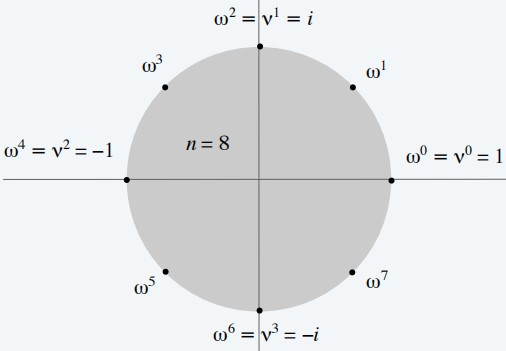

**Fact**. The $(n/2)^{th}$ roots of unity are: $\nu^0, \nu^1, \ldots, \nu^{n/2–1}$ where $\nu = \omega^2 = e^{4π i / n}$.

## Discrete Fourier transform

**Coefficient $\Rightarrow$ Point-value**. Given a polynomial $A(x) = a_0 + a_1 x + ... + a_{n–1} x^{n–1}$, evaluate it at $n$ distinct points $x_0, ..., x_{n–1}$.

**Key idea**. Choose $x_k = \omega^k$ where $\omega$ is principal $n^{th}$ root of unity.

$$\left[ \begin{array}{c}
y_{0} \\
y_{1} \\
y_{2} \\
y_{3} \\
\vdots \\
y_{n-1} \\
\end{array} \right]
=
\left[ \begin{array}{c}
1 & 1 & 1 & 1 & \cdots & 1 \\
1 & \omega^{1} & \omega^2 & \omega^3 & \cdots & \omega^{(n-1)} \\
1 & \omega^{2} & \omega^4 & \omega^6 & \cdots & \omega^{2(n-1)} \\
1 & \omega^{3} & \omega^6 & \omega^9 & \cdots & \omega^{3(n-1)} \\
\vdots & \vdots & \vdots & \vdots & \ddots & \vdots \\
1 & \omega^{n-1} & \omega^{2(n-1)} & \omega^{3(n-1)} & \cdots & \omega^{(n-1)(n-1)} \\
\end{array} \right]
\times
\left[ \begin{array}{c}
a_{0} \\
a_{1} \\
a_{2} \\
a_{3} \\
\vdots \\
a_{n-1} \\
\end{array} \right]$$

## Fast Fourier transform: steps

**Goal**. Evaluate a degree $n – 1$ polynomial $A(x) = a_0 + a_1 x + ... + a_{n–1} x^{n–1}$ at its $n^{th}$ roots of unity: $\omega^0, \omega^1, \ldots, \omega^{n–1}$.

**Divide**. Break up polynomial into even- and odd-degree terms.

- $A_{even}(x) = a_0+ a_2 x + a_4 x^2 + \ldots + a_{n-2} x^{n/2-1}$.
- $A_{odd}(x) = a_1 + a_3 x + a_5 x^2 + \ldots + a_{n-1} x^{n/2-1}$.
- $A(x) = A_{even}(x^2) + x A_{odd}(x^2)$.
- $A(-x) = A_{even}(x^2) - x A_{odd}(x^2)$.

**Conquer**. Evaluate $A_{even}(x)$ and $A_{odd}(x)$ at $(n/2)^{th}$ roots of unity: $\nu^0, \nu^1, \ldots, \nu^{n/2–1}$

**Combine**.

- $y_k = A(\omega^k) = A_{even}(\nu^k) + \omega^k A_{odd}(\nu^k), 0 \le k < n/2$.
- $y_{k+ n/2} = A(\omega^{k+ n/2}) = A_{even}(\nu^k) – \omega^k A_{odd}(\nu^k), 0 \le k < n/2$.

## Fast Fourier transform: algorithm

1. IF ($n = 1$): RETURN $a_0$;
2. $(e_0, e_1, \ldots, e_{n/2–1})$ = `FFT`($n / 2, a_0, a_2, a_4, \ldots, a_{n–2}$);
3. $(d_0, d_1, \ldots, d_{n/2–1})$ = `FFT`($n / 2, a_1, a_3, a_5, \ldots, a_{n–1}$);
4. FOR $k = 0 .. n / 2 – 1$:
   1. $\omega^k = e^{2π i k/n}$;
   2. $y_k = e_k + \omega^k d_k$;
   3. $y_{k + n/2} = e_k – \omega^k d_k$;
5. RETURN ($y_0, y_1, y_2, \ldots, y_{n–1}$).

**Time**.

- `2-3`: $2 T(n/2)$
- `4.1-4.3`: $\Theta(n)$

## FFT: analysis

**Theorem**. The FFT algorithm evaluates a degree $n – 1$ polynomial at each of the $n^{th}$ roots of unity in $O(n \log n)$ arithmetic operations and $O(n)$ extra space.  
**Pf**.

$$T(n) = \left\{ \begin{array}{lcl}
\Theta(1) & \text{if} & n = 1 \\
2 T(n/2) + \Theta(n) & \text{if} & n > 1 \\
\end{array}\right.$$

## Quiz: FFT tree

When computing the FFT of $(a_0, a_1, a_2, \dots, a_7)$, which are the first two coefficients involved in an arithmetic operation?

**A**. $a_0$ and $a_1$.  
**B**. $a_0$ and $a_2$.  
**C**. $a_0$ and $a_4$.  
**D**. $a_0$ and $a_7$.  
**E**. None of the above.

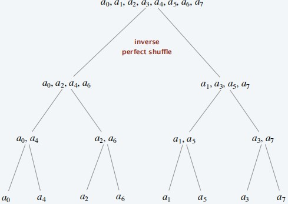

C: first leaf of the FFT tree.

## FFT: Fourier matrix decomposition

**Alternative viewpoint**. FFT is a recursive decomposition of Fourier matrix.

$$F_n =
\left[ \begin{array}{c}
1 & 1 & 1 & 1 & \cdots & 1 \\
1 & \omega^{1} & \omega^2 & \omega^3 & \cdots & \omega^{(n-1)} \\
1 & \omega^{2} & \omega^4 & \omega^6 & \cdots & \omega^{2(n-1)} \\
1 & \omega^{3} & \omega^6 & \omega^9 & \cdots & \omega^{3(n-1)} \\
\vdots & \vdots & \vdots & \vdots & \ddots & \vdots \\
1 & \omega^{n-1} & \omega^{2(n-1)} & \omega^{3(n-1)} & \cdots & \omega^{(n-1)(n-1)} \\
\end{array} \right]
a =
\left[ \begin{array}{c}
a_{0} \\
a_{1} \\
a_{2} \\
\vdots \\
a_{n-1} \\
\end{array} \right]$$

$$I_n =
\left[ \begin{array}{c}
1 & 0 & 0 & \cdots & 0 \\
0 & 1 & 0 & \cdots & 0 \\
0 & 0 & 1 & \cdots & 0 \\
\vdots & \vdots & \vdots & \ddots & \vdots \\
0 & 0 & 0 & \cdots & 1 \\
\end{array} \right]
D_n =
\left[ \begin{array}{c}
\omega^{0} & 0 & 0 & \cdots & 0 \\
0 & \omega^{1} & 0 & \cdots & 0 \\
0 & 0 & \omega^{2} & \cdots & 0 \\
\vdots & \vdots & \vdots & \ddots & \vdots \\
0 & 0 & 0 & \cdots & \omega^{n-1} \\
\end{array} \right]$$

$$y = F_n a =
\left[ \begin{array}{c}
I_{n/2} & D_{n/2} \\
I_{n/2} & -D_{n/2} \\
\end{array} \right]
\left[ \begin{array}{c}
F_{n/2} a_{even} \\
F_{n/2} a_{odd} \\
\end{array} \right]$$

## Inverse discrete Fourier transform

**Point-value $\Rightarrow$ Coefficient**. Given $n$ distinct points $x_0, ..., x_{n–1}$ and values $y_0, ..., y_{n–1}$, find unique polynomial $A(x) = a_0 + a_1 x + ... + a_{n–1} x^{n–1}$, that has given values at given points.

$$\left[ \begin{array}{c}
a_{0} \\
a_{1} \\
a_{2} \\
a_{3} \\
\vdots \\
a_{n-1} \\
\end{array} \right]
=
\left[ \begin{array}{c}
1 & 1 & 1 & 1 & \cdots & 1 \\
1 & \omega^{1} & \omega^2 & \omega^3 & \cdots & \omega^{(n-1)} \\
1 & \omega^{2} & \omega^4 & \omega^6 & \cdots & \omega^{2(n-1)} \\
1 & \omega^{3} & \omega^6 & \omega^9 & \cdots & \omega^{3(n-1)} \\
\vdots & \vdots & \vdots & \vdots & \ddots & \vdots \\
1 & \omega^{n-1} & \omega^{2(n-1)} & \omega^{3(n-1)} & \cdots & \omega^{(n-1)(n-1)} \\
\end{array} \right]^{-1}
\left[ \begin{array}{c}
y_{0} \\
y_{1} \\
y_{2} \\
y_{3} \\
\vdots \\
y_{n-1} \\
\end{array} \right]$$

## Inverse FFT

**Claim**. Inverse of Fourier matrix $F_n$ is given by following formula:

$$G_n = \frac{1}{n} =
\left[ \begin{array}{c}
1 & 1 & 1 & 1 & \cdots & 1 \\
1 & \omega^{-1} & \omega^{-2} & \omega^{-3} & \cdots & \omega^{-(n-1)} \\
1 & \omega^{-2} & \omega^{-4} & \omega^{-6} & \cdots & \omega^{-2(n-1)} \\
1 & \omega^{-3} & \omega^{-6} & \omega^{-9} & \cdots & \omega^{-3(n-1)} \\
\vdots & \vdots & \vdots & \vdots & \ddots & \vdots \\
1 & \omega^{-(n-1)} & \omega^{-2(n-1)} & \omega^{-3(n-1)} & \cdots & \omega^{-(n-1)(n-1)} \\
\end{array} \right]$$

**Consequence**. To compute the inverse FFT, apply the same algorithm but use $\omega^{–1} = e^{–2π i / n}$ as principal $n^{th}$ root of unity (and divide the result by $n$).

## Inverse FFT: correctness

**Claim**. $F_n$ and $G_n$ are inverses.  
**Pf**.

$$(F_n G_n)_{k k'} = \frac{1}{n} \sum_{j=0}^{n-1} \omega^{kj} \omega^{-jk'} = \frac{1}{n} \sum_{j=0}^{n-1} \omega^{(k-k')j} =
\left\{ \begin{array}{lll}
1 & \text{if}\ k = k \\
0 & \text{otherwise} \\
\end{array}\right.$$

## Inverse FFT: correctness (cont.)

**Summation lemma**. Let $\omega$ be a principal $n^{th}$ root of unity. Then

$$\sum_{j=0}^{n-1} \omega^{kj} =
\left\{ \begin{array}{lll}
n & \text{if}\ k \equiv 0 \pmod{0} \\
0 & \text{otherwise} \\
\end{array}\right.$$

**Pf**.

- If $k$ is a multiple of $n$, then $\omega^k = 1 \Rightarrow$ series sums to $n$.
- Each $n^{th}$ root of unity $\omega^k$ is a root of $x^n – 1 = (x – 1) (1 + x + x^2 + ... + x^{n−1})$.
- if $\omega^k \ne 1$, then $1 + \omega^k + \omega^{k(2)} + … + \omega^{k(n−1)} = 0 \Rightarrow$ series sums to 0.

## Inverse FFT: algorithm

1. IF ($n = 1$): RETURN $y_0$;
2. $(e_0, e_1, \ldots, e_{n/2–1})$ = `INVERSE-FFT`($n / 2, y_0, y_2, y_4, \ldots, y_{n–2}$);
3. $(d_0, d_1, \ldots, d_{n/2–1})$ = `INVERSE-FFT`($n / 2, y_1, y_3, y_5, \ldots, y_{n–1}$);
4. FOR $k = 0 .. n / 2 – 1$:
   1. $\omega^k = e^{-2π i k/n}$;
   2. $a_k = e_k + \omega^k d_k$;
   3. $a_{k + n/2} = e_k – \omega^k d_k$;
5. RETURN ($a_0, a_1, a_2, \ldots, a_{n–1}$);

**Time**.

- `2-3`: $2 T(n/2)$
- `4.1-4.3`: $\Theta(n)$

## Inverse FFT: analysis

**Theorem**. The inverse FFT algorithm interpolates a degree $n – 1$ polynomial at each of the $n^{th}$ roots of unity in $O(n \log n)$ arithmetic operations.

- assumes $n$ is a power of 2

**Corollary**. Can convert between coefficient and point-value representations in $O(n \log n)$ arithmetic operations.

| coefficient | transform | point-value |
| --- | --- | --- |
| coefficient | FFT: $O(n \log n)$ | point-value |
|  |  | multiplication: $O(n)$ |
| coefficient | inv. FFT: $O(n \log n)$ | point-value |

## Polynomial multiplication

**Theorem**. Given two polynomials $A(x) = a_0 + a_1 x + a_2 x^2 + \ldots + a_{n−1} x^{n−1}$ and $B(x) = b_0 + b_1 x + b_2 x^2 + \ldots + b_{n−1} x^{n−1}$ of degree $n – 1$, can multiply them in $O(n \log n)$ arithmetic operations.

- pad with 0s to make $n$ a power of 2

**Pf**.

| coefficient | transform | point-value |
| --- | --- | --- |
| coefficient | FFT: $O(n \log n)$ | point-value |
|  |  | multiplication: $O(n)$ |
| coefficient | inv. FFT: $O(n \log n)$ | point-value |

## Convolution

**Convolution**. A vector with $2n -1$ coordinates, where $c_k = \sum_{(i,j):i+j=k} a_i b_j$.

- $a \ast b = (a_0 b_0, a_0 b_1 + a_1 b_0, a_0 b_2 + a_1 b_1 + a_2 b_0, ..., a_{n−2} b_{n−1} + a_{n−1} b_{n−2}, a_{n−1} b_{n−1})$.
  - exactly the coordinates of polynomial multiplication.
- summing along anti-diagonals of the following matrix.

$$\left[ \begin{array}{c}
a_0 b_0 & a_0 b_1 & a_0 b_2 & a_0 b_3 & \cdots & a_0 b_{n-1} \\
a_1 b_0 & a_1 b_1 & a_1 b_2 & a_1 b_3 & \cdots & a_1 b_{n-1} \\
a_2 b_0 & a_2 b_1 & a_2 b_2 & a_2 b_3 & \cdots & a_2 b_{n-1} \\
a_3 b_0 & a_3 b_1 & a_3 b_2 & a_3 b_3 & \cdots & a_3 b_{n-1} \\
\vdots & \vdots & \vdots & \vdots & \ddots & \vdots \\
a_{n-1} b_0 & a_{n-1} b_1 & a_{n-1} b_2 & a_{n-1} b_3 & \cdots & a_{n-1} b_{n-1} \\
\end{array} \right]$$

## Integer multiplication, revisit

**Integer multiplication**. Given two n-bit integers $a = a_{n–1} … a_1 a_0$ and $b = b_{n–1} … b_1 b_0$, compute their product $a \cdot b$.

**Convolution algorithm**.

- Form two polynomials.
  - $A(x) = a_0 + a_1 x + a_2 x^2 + \ldots + a_{n−1} x^{n−1}$
  - $B(x) = b_0 + b_1 x + b_2 x^2 + \ldots + b_{n−1} x^{n−1}$
  - Note: $a = A(2), b = B(2)$.
- Compute $C(x) = A(x) \cdot B(x)$.
- Evaluate $C(2) = a \cdot b$.
- Running time: $O(n \log n)$ floating-point operations.

**Practice**. [GNU Multiple Precision Arithmetic Library]

- Switches to FFT-based algorithm when $n$ is large ($\ge$ 5–10K).

## 3-Sum: revisit

**3-SUM**. Given three sets $X$, $Y$, and $Z$ of $n$ integers each, determine whether there is a triple $i \in X, j \in Y, k \in Z$ such that $i + j = k$.

**Assumption**. All integers are between $0$ and $m$.

**Goal**. $O(m \log m + n \log n)$ time.

**Ex**.

$m = 19, n = 3$

- $X = \{ 4, 7, 10 \}$
- $Y = \{ 5, 8, 15 \}$
- $Z = \{ 4, 13, 19 \}$

$4 + 15 = 19$

## 3-Sum: solution

**An $O(m \log m + n)$ solution**.

- Form polynomial $A(x) = a_0 + a_1 x + \ldots + a_m x^m$ with $a_i = 1$ iff $i \in X$.
- Form polynomial $B(x) = b_0 + b_1 x + \ldots + b_m x^m$ with $b_j = 1$ iff $j \in Y$.
- Compute product/convolution $C(x) = A(x) \times B(x)$.
- The coefficient $c_k$ = number of ways to choose an integer $i \in X$ and an integer $j \in Y$ that sum to exactly $k$.
- For each $k \in Z$: check whether $c_k > 0$.

**Ex**.

$m = 19, n = 3$

- $X = \{ 4, 7, 10 \}$
- $Y = \{ 5, 8, 15 \}$
- $Z = \{ 4, 13, 19 \}$

$4 + 15 = 19$

$$\begin{aligned}
A(x) & = x^4 + x^7 + x^{10} \\
B(x) & = x^{5} + x^{8} + x^{15} \\
C(x) & = x^{9} + 2x^{12} + 2x^{15} + x^{18} + x^{19} + x^{22} + x^{25} \\
\end{aligned}$$